# Hapiness Study

Amit Goldenberg

Stanford students were asked about their happiness and a few other measures.

#### Scales:

**Expct happiness(Amit Invented)- 1-7 scale**

Expecting happy emotions: 1. I nearly always expect to feel happy. 2. I rarely expect to feel happy. 3. In most situations, I expect to feel happy. 4. I feel surprised whenever I feel happy.

Not expecting unhappy emotions: 1. I nearly always expect to feel unhappy. 2. I rarely expect to feel unhappy. 3. In most situations, I expect to feel unhappy. 4. I feel surprised whenever I feel unhappy.

**Value Happiness (Iris Mauss) - 1-7 scale**

1. How happy I am at any given moment says a lot about how worthwhile my life is.
2. If I don’t feel happy, maybe there is something wrong with me.
3. I value things in life only to the extent that they influence my personal happiness.
4. I would like to be happier than I generally am.
5. Feeling happy is extremely important to me.
6. I am concerned about my happiness even when I feel happy.
7. To have a meaningful life, I need to feel happy most of the time.

**Satisfaction with Life (SWL): 1-7 scale**

1. In most ways my life is close to ideal.
2. The conditions of my life are excellent.
3. I am satisfied with my life.
4. So far I have gotten the important things I want in life.
5. If I could live my life over, I would change almost nothing.

**Ryff Scales of Psychological Well-Being: 1-6 scale**

1. I tend to be influenced by people with strong opinions.
2. I live life one day at a time and don’t really think about the future.
3. For me, life has been a continuous process of learning, changing, and growth.
4. In many ways, I feel disappointed about my achievements in life.
5. The demands of everyday life often get me down.
6. I sometimes feel as if I’ve done all there is to do in life.
7. I judge myself by what I think is important, not by the values of what others think is important.
8. I have not experienced many warm and trusting relationships with others.
9. I like most aspects of my personality.
10. I have confidence in my opinions, even if they are contrary to the general consensus.
11. Some people wander aimlessly through life, but I am not one of them.
12. I think it is important to have new experiences that challenge how you think about yourself and the world.
13. Maintaining close relationships has been difficult and frustrating for me.
14. When I look at the story of my life, I am pleased with how things have turned out.
15. People would describe me as a giving person, willing to share my time with others.
16. In general, I feel I am in charge of the situation in which I live.
17. I am quite good at managing the many responsibilities of my daily life.
18. I gave up trying to make big improvements or changes in my life a long time ago.

**BDI** Depression - Bdi 1. I do not feel sad. I feel sad or blue. I am blue or sad all the time and I can’t snap out of it. I am so sad or unhappy that I can’t stand it. 2. I do not feel that the future is hopeless and that things cannot improve. I feel discouraged about the future. I feel I have nothing to look forward to. I feel that the future is hopeless and that things cannot improve. 3. I do not feel like a failure. I feel I have failed more than the average person. As I look back on my life, all I can see is a lot of failures. I feel I am a complete failure as a person (parent, husband, wife). 4. I am not particularly dissatisfied. I don’t enjoy things the way I used to. I don’t get real satisfaction out of anything anymore. I am dissatisfied with everything. 5. I don’t feel particularly guilty. I feel bad or unworthy a good part of the time. I feel quite guilty. I feel as though I am very bad or worthless. 6. I don’t feel disappointed in myself. I am disappointed in myself. I am disgusted with myself. I hate myself. 7. I have not lost interest in other people. I am less interested in other people than I used to be. I have lost most of my interest in other people and have little feeling for them. I have lost all of my interest in other people and don’t care about them at all. 8. I make decisions about as well as ever. I try to put off making decisions. I have great difficulty in making decisions. I can’t make any decisions at all anymore. 9. I don’t feel that I look any worse than I used to. I am worried that I am looking old or unattractive. I feel that there are permanent changes in my appearance that make me look unattractive. I believe that I am ugly or repulsive-looking.

10. I don’t get more tired than usual. I get tired more easily than I used to. I get tired from doing almost anything. I am too tired to do anything.
11. I can work about as well as before. It takes an extra effort to get started at doing something. I have to push myself very hard to do anything. I can’t do any work at all.
12. My appetite is no worse than usual. My appetite is not as good as it used to be. My appetite is much worse now. I have no appetite at all anymore.

**Depression - CES:**

0 = Rarely or none of the time (less than 1 day) 1 = Some or a little of the time (1-2 days) 2 = Occasionally or moderate amount of time (3-4 days) 3 = Most or all of the time (5-7 days)

1. I felt depressed.
2. My sleep was restless.
3. I felt lonely.
4. I had crying spells.
5. I could not ‘get going.’

# Reads in the data file

```r
table (d$gender)
```

```
female   male
   158     93
```

**correlation table**

```r
cor_table = data.frame (d$expectScale, d$valueScale ,d$swlScale, d$ryffScale, d$bdiScale, d$cesScale)
colnames(cor_table) <- c("expect", "value", "swl", "ryff", "bdi" , "ces"  )
cor_table1 = cor(cor_table)
cor_table_round = round(cor_table1, digits = 2)
cor_table_round
```

```
       expect value   swl  ryff   bdi   ces
expect   1.00  0.03  0.37  0.42 -0.34 -0.33
value    0.03  1.00 -0.17 -0.26  0.28  0.28
swl      0.37 -0.17  1.00  0.56 -0.37 -0.29
ryff     0.42 -0.26  0.56  1.00 -0.47 -0.39
bdi     -0.34  0.28 -0.37 -0.47  1.00  0.68
ces     -0.33  0.28 -0.29 -0.39  0.68  1.00
```

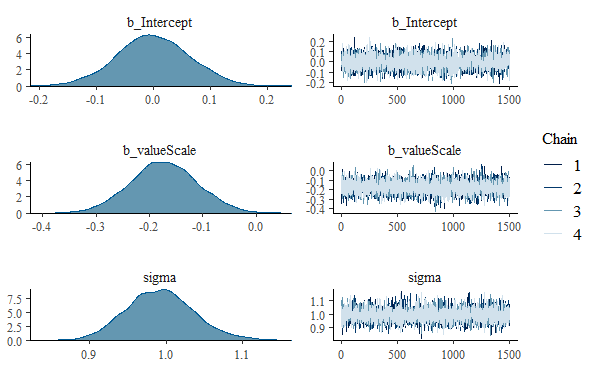

**a frequentist confidnce interval** - if we drew 100 similar samples with the same procedure, 95 you would get the same estimate

**a Bayesian credible intervale** - Your confidence that the parameter lies within that interval.

We are changing the prior on the sigma valuation to be exponential

```r
print(b2)
```

```
 Family: gaussian
  Links: mu = identity; sigma = identity
Formula: swlScale ~ 1 + valueScale
   Data: ds (Number of observations: 251)
Samples: 4 chains, each with iter = 2000; warmup = 500; thin = 1;
         total post-warmup samples = 6000

Population-Level Effects:
           Estimate Est.Error l-95% CI u-95% CI Eff.Sample Rhat
Intercept      0.00      0.06    -0.12     0.12       6147 1.00
valueScale    -0.17      0.06    -0.30    -0.05       5250 1.00

Family Specific Parameters:
      Estimate Est.Error l-95% CI u-95% CI Eff.Sample Rhat
sigma     0.99      0.04     0.91     1.08       6082 1.00

Samples were drawn using sampling(NUTS). For each parameter, Eff.Sample
is a crude measure of effective sample size, and Rhat is the potential
scale reduction factor on split chains (at convergence, Rhat = 1).
```

get sample distributions of the data

[output not shown]

[output cut: 990 more lines]